# Case Study 1

AKSTA Statistical Computing

Bence Vass and Maria-Theresia Dvorak

2024-04-16

### 1. Ratio of Fibonacci numbers

1. Write two different R functions which return the sequence $r_i = F_{i+1} /F_i$ for i = 1, . . . , n where $F_i$ is the i-th Fibonacci number, once using **for** and once using **while**.

```r
fib_ratio_for <- function(x) {
  fib <- c(1, 1)
  ratio <- c()

  for (i in 3:x) {
    ratio <- c(ratio, fib[i - 1] / fib[i - 2])
    fib <- c(fib, fib[i - 1] + fib[i - 2])
  }

  return(ratio)
}

print(fib_ratio_for(10))
```

```
## [1] 1.000000 2.000000 1.500000 1.666667 1.600000 1.625000 1.615385 1.619048
```

At first we are using a for loop to determine $r_i$. We define a vector `fib` with the first values (1,1) and an empty vector ratio. The Function `fib_ratio` calculates the Fibonacci number $F_{n-1}+F_{n-2}$ and use them to determine our ratio. Then we append this ratio to the vector `ratio`.

```r
fib_ratio_while <- function(x) {
  fib <- c(1, 1)
  ratio <- c()
  i <- 3
  while (i <= x) {
    fib[i] <- fib[i - 1] + fib[i - 2]
    ratio <- c(ratio, fib[i - 1] / fib[i - 2])
    i <- i + 1
  }

  return(ratio)
}

print(fib_ratio_while(10))
```

```
## [1] 1.000000 2.000000 1.500000 1.666667 1.600000 1.625000 1.615385 1.619048
```

The first steps are the same like before, but we have to initialize our index i too. Here iterates the loop until the certain condition (i <= x) is met. Furthermore it’s important to increase i by 1 in our loop.

2. Benchmark the two functions for $n = 200$ and $n = 2000$ (you can use package **microbenchmark** or package **bench** for this purpose). Which function is faster?

```r
library("bench")

n1 <- 200
n2 <- 2000
mark(fib_ratio_while(n1), fib_ratio_for(n1), iterations=100)
```

```
## # A tibble: 2 × 6
##   expression               min   median `itr/sec` mem_alloc `gc/sec`
##   <bch:expr>          <bch:tm> <bch:tm>     <dbl> <bch:byt>    <dbl>
## 1 fib_ratio_while(n1)    217µs    302µs     3123.     191KB      0
## 2 fib_ratio_for(n1)      242µs    402µs     2828.     326KB     28.6
```

```r
mark(fib_ratio_while(n2), fib_ratio_for(n2), iterations=100)
```

```
## # A tibble: 2 × 6
##   expression               min   median `itr/sec` mem_alloc `gc/sec`
##   <bch:expr>          <bch:tm> <bch:tm>     <dbl> <bch:byt>    <dbl>
## 1 fib_ratio_while(n2)   6.51ms   7.51ms     126.     15.7MB     56.8
## 2 fib_ratio_for(n2)    11.86ms  12.29ms      80.5    30.7MB    121.
```

Here we are running each function 100 times to get a more accurate estimate of the typical execution time. This benchmarks indicate that the `fib_ratio_while` function generally performs faster than the `fib_ratio_for` function for both $n = 200$ and $n = 2000$. This suggests that the while loop implementation is more efficient in this case compared to the for loop implementation.

3. Plot the sequence for $n = 100$. For which value n it starts to converge? What is the number that it converges to?

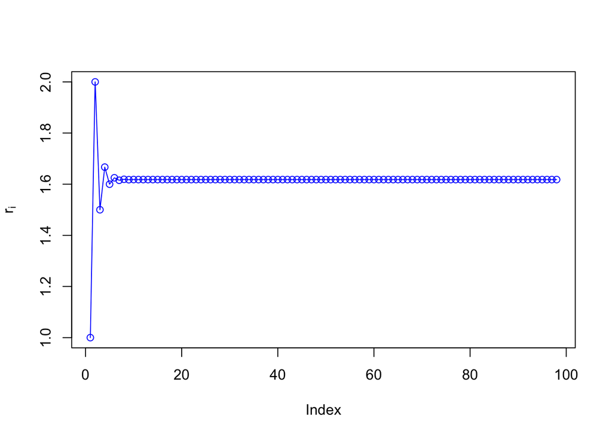

```r
plot(fib_ratio_while(100), col='blue', ylab=expression("r"[i]))
lines(fib_ratio_while(100), col='blue')
```

```r
fib_ratio_while(100)
```

```
##  [1] 1.000000 2.000000 1.500000 1.666667 1.600000 1.625000 1.615385 1.619048
##  [9] 1.617647 1.618182 1.617978 1.618056 1.618026 1.618037 1.618033 1.618034
## [17] 1.618034 1.618034 1.618034 1.618034 1.618034 1.618034 1.618034 1.618034
## [25] 1.618034 1.618034 1.618034 1.618034 1.618034 1.618034 1.618034 1.618034
## [33] 1.618034 1.618034 1.618034 1.618034 1.618034 1.618034 1.618034 1.618034
## [41] 1.618034 1.618034 1.618034 1.618034 1.618034 1.618034 1.618034 1.618034
## [49] 1.618034 1.618034 1.618034 1.618034 1.618034 1.618034 1.618034 1.618034
## [57] 1.618034 1.618034 1.618034 1.618034 1.618034 1.618034 1.618034 1.618034
## [65] 1.618034 1.618034 1.618034 1.618034 1.618034 1.618034 1.618034 1.618034
## [73] 1.618034 1.618034 1.618034 1.618034 1.618034 1.618034 1.618034 1.618034
## [81] 1.618034 1.618034 1.618034 1.618034 1.618034 1.618034 1.618034 1.618034
## [89] 1.618034 1.618034 1.618034 1.618034 1.618034 1.618034 1.618034 1.618034
## [97] 1.618034 1.618034
```

From the sequence of ratios, we observe that starting from n = 4, the value of $r_n$ gradually approaches the limit of the sequence. By n = 16, we reach the limit, which is approximately 1.618034, known as the golden ratio.

### 2. Gamma function

1. Write a function to compute the following for n a positive integer using the gamma function in base R.
   $$\rho_n = \frac{Γ((n − 1)/2)}{Γ(1/2)Γ((n − 2)/2)}$$

```r
p <- function(n){
  gamma((n-1)/2)/(gamma(1/2)*gamma((n-2)/2))
}
```

2. Try $n = 2000$. What do you observe? Why do you think the observed behavior happens?

```r
p(2000)
```

```
## [1] NaN
```

With n=2000 we receive NaN (Not a Number). It suggests that the computation encountered numerical issues, likely due to overflow or underflow errors when dealing with very large numbers.

3. Write an implementation which can also deal with large values of $n > 1000$.

```r
p_new <- function(n){
  rho <- lgamma((n-1)/2)-(lgamma(1/2)+lgamma((n-2)/2))
  exp(rho)
}
p_new(2000)
```

```
## [1] 17.83009
```

Here we use `lgamma` to compute the natural logarithm of the gamma function. Then with `exp` we finally get our result. This method should handle large values of n effectively without encountering numerical instability issues.

4. Plot $\rho_n/\sqrt{n}$ for different values of n. Can you guess the limit of $\rho_n / \sqrt{n}$ for $n \rightarrow \infty$?

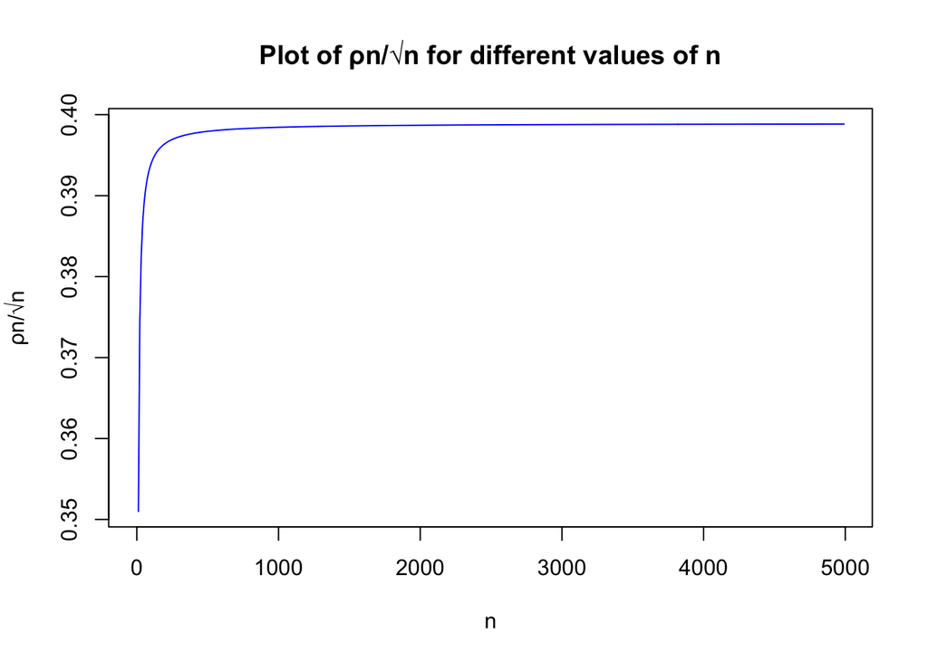

```r
n_values <- seq(1,5000, by=10)
p_sqrt_n  <- function(n){
  p_new(n)/sqrt(n)
}
p_sqrt_n_values <- sapply(n_values, p_sqrt_n)

plot(n_values, p_sqrt_n_values, type = "l",
     xlab = "n", ylab = "ρn/√n",
     main = "Plot of ρn/√n for different values of n", col = "blue")
```

### 3. The golden ratio

Two positive numbers x and y with x > y are said to be in the golden ratio if the ratio between the larger number and the smaller number is the same as the ratio between their sum and the larger number:
$$\frac{x}{y}=\frac{x+y}{x}$$
(a) Write an R function which computes $\Phi^{n+1}$ using the recursion above (go up to n = 1000).

```r
memo <- numeric(1000)
phi_power <- function(n) {
  if (n == 0) {
    return((sqrt(5) + 1) / 2)
  } else if (n == 1) {
    return(((sqrt(5) + 1) / 2)^2)
  } else {
    if (memo[n] == 0) {
      phi_n <- phi_power(n - 1)
      phi_n_minus_1 <- phi_power(n - 2)
      memo[n] <<- phi_n + phi_n_minus_1
    }
    return(memo[n])
  }
}

for (n in 0:10) {
  phi_n_plus_1 <- phi_power(n)
  print(paste("Phi^", n+1, " =", phi_n_plus_1))
}
```

```
## [1] "Phi^ 1  = 1.61803398874989"
## [1] "Phi^ 2  = 2.61803398874989"
## [1] "Phi^ 3  = 4.23606797749979"
## [1] "Phi^ 4  = 6.85410196624968"
## [1] "Phi^ 5  = 11.0901699437495"
## [1] "Phi^ 6  = 17.9442719099992"
## [1] "Phi^ 7  = 29.0344418537486"
## [1] "Phi^ 8  = 46.9787137637478"
## [1] "Phi^ 9  = 76.0131556174964"
## [1] "Phi^ 10  = 122.991869381244"
## [1] "Phi^ 11  = 199.005024998741"
```

The function checks if $n = 0$, the function returns $\Phi^1 =(\sqrt{5} + 1) / 2$. If $n = 1$, the function returns $\left((\sqrt{5} + 1) / 2\right)^2$. For $n > 1$, the function recursively calculates $\Phi^{n-1}$ and $\Phi^{n-2}$ by calling itself with $n - 1$ and $n - 2$ as arguments. It then returns the sum of these two values, which corresponds to $\Phi^n + \Phi^{n-1}$ according to the Fibonacci-like relationship.

2. Write a function which computes this $\Phi^{n+1}$ by simply using the power operator ^.

```r
phi_power_simple <- function(n) {
  phi <- (sqrt(5) + 1) / 2
  return(phi^(n+1))
}

for (n in 0:10) {
  phi_n_plus_1 <- phi_power_simple(n)
  print(paste("Phi^", n+1, " =", phi_n_plus_1))
}
```

```
## [1] "Phi^ 1  = 1.61803398874989"
## [1] "Phi^ 2  = 2.61803398874989"
## [1] "Phi^ 3  = 4.23606797749979"
## [1] "Phi^ 4  = 6.85410196624969"
## [1] "Phi^ 5  = 11.0901699437495"
## [1] "Phi^ 6  = 17.9442719099992"
## [1] "Phi^ 7  = 29.0344418537486"
## [1] "Phi^ 8  = 46.9787137637478"
## [1] "Phi^ 9  = 76.0131556174965"
## [1] "Phi^ 10  = 122.991869381244"
## [1] "Phi^ 11  = 199.005024998741"
```

3. Use once == and once all.equal to compare $\Phi^{n+1}$ obtained in a. vs the one obtained in b. for $n = 12, 60, 120, 300$. What do you observe? If there are any differences, what can be the reason?

```r
n_values <- c(12, 60, 120, 300)

for (n in n_values) {
  result_a <- phi_power(n)
  print(result_a)
  result_b <- phi_power_simple(n)
  print(result_b)

  cat("For n =", n, ", results are equal using ==:", result_a == result_b, "\n")

  cat("For n =", n, ", results are equal using all.equal:", all.equal(result_a, result_b), "\n\n")
}
```

```
## [1] 521.0019
## [1] 521.0019
## For n = 12 , results are equal using ==: FALSE
## For n = 12 , results are equal using all.equal: TRUE
##
## [1] 5.600748e+12
## [1] 5.600748e+12
## For n = 60 , results are equal using ==: FALSE
## For n = 60 , results are equal using all.equal: TRUE
##
## [1] 1.938673e+25
## [1] 1.938673e+25
## For n = 120 , results are equal using ==: FALSE
## For n = 120 , results are equal using all.equal: TRUE
##
## [1] 8.040438e+62
## [1] 8.040438e+62
## For n = 300 , results are equal using ==: FALSE
## For n = 300 , results are equal using all.equal: TRUE
```

From the output, we observe that the results obtained from the two methods, `phi_power` and `phi_power_simple`, are not exactly equal when using the equality operator `==`, but they are considered equal when using the `all.equal` function. This discrepancy arises due to differences in how floating-point arithmetic is handled in the two methods. The `==` operator checks for exact equality, which may fail due to small rounding errors in floating-point calculations. On the other hand, the `all.equal` function compares values within a specified tolerance level and considers them equal if they are sufficiently close, which is why it returns TRUE for all comparisons.

### 4. Game of craps

A variation of game of craps is played as follows. The player rolls a die and if they roll a 6, they immediately wins. If a 1 is rolled, they immediately loses. If a 2, 3, 4, or 5 is rolled, then this number becomes their “point number”. The player then has up to three more rolls of the die to roll their point number again. If they do, they win otherwise they lose. Write a program in R to simulate a game of craps. Explain the steps of your program. If the code is not explained, no points will be earned.

```r
point_number = sample(1:6, 1) # get a number from 1 to 6 - player rolls a die
cat('You have rolled: ', point_number ,'\n')
```

```
## You have rolled:  2
```

```r
if(point_number == 6){
  # if the rolled number is 6 player wins immediately
  cat('You win!')

} else if (point_number == 1){
  # if the rolled number is 1 player loses immediately
  cat('You lose!')

} else {
  # handles remaining cases ( rolled: 2 | 3 | 4 | 5 )
  cat('Your point number is: ', point_number, '\n')

  won = FALSE # set true if player rolls their point number (redundant if simul. is a func.)

  for (i in 1:3){
    # repeat die roll up to 3 times

    roll = sample(1:6, 1) # get a number from 1 to 6 - player rolls a die
    cat('On ',i, '. roll you got: ', roll, '\n')

    if(roll == point_number){
      # handles "point number" has been rolled again - player wins

      cat('You win!')
      won = TRUE # (redundant if simul. is a func.)
      break # exit the loop, no more repeation is necessary
    }
  }


  if(!won){
    # handles "point number" has not been rolled out of the three repetition
    #(redundant if simul. is a func.)

    cat('You lose!')
  }

}
```

```
## Your point number is:  2
## On  1 . roll you got:  5
## On  2 . roll you got:  2
## You win!
```

### 5. Readable and efficient code

Read over the code below.

1. Explain (in text) what the code does.

   *Generate 1000 random data samples x based on normal distribution and based on x and an other normal normal distribution further 1000 samples y are generated.*

   *The generated data will be separated, such that a quarter of it will be predicted by a linear model fitted on the remaining data samples. This process is repeated four times in 1-250, 250-500, 500-750, 750-1000 splits. On each quarter the square root of the mean squared error is collected in a vector and printed at the end.*
2. Explain (in text) what you would change to make the code more readable.

   *I would make the indexing of the splits easier readable, a function for the prediction and use a loop to eliminate redundancy.*
3. Change the code according to a. and wrap it in a function. This function should have at most 10 lines (without adding commands to more lines such as x <- 1; y <- 2. Such commands will count as 2 lines!). Check that the function called on the same input outputs the same as the provided code.

   ```r
   set.seed(1)
   x <- rnorm(1000)
   y <- 2 + x + rnorm(1000)
   df <- data.frame(x, y)

   sqrt_mse = function(df){
     r = c()
     for(i in 1:4){
       idx = (((i - 1) * 250) + 1) : (i * 250)
       m = lm(y ~ x, data = df[-idx,])
       pred =  predict(m, newdata = df[idx,])
       r[i] = sqrt(mean((pred - df[idx,"y"])^2))
     }
     return(r)
   }

   sqrt_mse(df)
   ```

   ```
   ## [1] 1.0249956 0.9952113 1.0685500 1.0707264
   ```

**Original Code**

```r
set.seed(1)
x <- rnorm(1000)
y <- 2 + x + rnorm(1000)
df <- data.frame(x, y)

cat("Step", 1, "\n")
```

```
## Step 1
```

```r
fit1 <- lm(y ~ x, data = df[-(1:250),])
p1 <- predict(fit1, newdata = df[(1:250),])
r <- sqrt(mean((p1 - df[(1:250),"y"])^2))

cat("Step", 2, "\n")
```

```
## Step 2
```

```r
fit2 <- lm(y ~ x, data = df[-(251:500),])
p2 <- predict(fit2, newdata = df[(251:500),])
r <- c(r, sqrt(mean((p2 - df[(251:500),"y"])^2)))

cat("Step", 3, "\n")
```

```
## Step 3
```

```r
fit3 <- lm(y ~ x, data = df[-(501:750),])
p3 <- predict(fit3, newdata = df[(501:750),])
r <- c(r, sqrt(mean((p3 - df[(501:750),"y"])^2)))

cat("Step", 4, "\n")
```

```
## Step 4
```

```r
fit4 <- lm(y ~ x, data = df[-(751:1000),])
p4 <- predict(fit4, newdata = df[(751:1000),])
r <- c(r, sqrt(mean((p4 - df[(751:1000),"y"])^2)))
r
```

```
## [1] 1.0249956 0.9952113 1.0685500 1.0707264
```

### 6. Measuring and improving performance

Have a look at the code of the function below. It is a function for performing a Kruskal Wallis test, a robust non-parametric method for testing whether samples come from the same distribution. (Note: we assume no missing values are present in x).

```r
kwtest <- function (x, g, ...) {
  if (is.list(x)) {
    if (length(x) < 2L)
      stop("'x' must be a list with at least 2 elements")
    if (!missing(g))
      warning("'x' is a list, so ignoring argument 'g'")
    if (!all(sapply(x, is.numeric)))
      warning("some elements of 'x' are not numeric and will be coerced to numeric")
    k <- length(x)
    l <- lengths(x)
    if (any(l == 0L))
      stop("all groups must contain data")
    g <- factor(rep.int(seq_len(k), l))
    x <- unlist(x)
  } else {
    if (length(x) != length(g))
      stop("'x' and 'g' must have the same length")
    g <- factor(g)
    k <- nlevels(g)
    if (k < 2L)
      stop("all observations are in the same group")
  }
  n <- length(x)
  if (n < 2L)
    stop("not enough observations")
  r <- rank(x)
  TIES <- table(x)
  STATISTIC <- sum(tapply(r, g, sum)^2/tapply(r, g, length))
  STATISTIC <- ((12 * STATISTIC/(n * (n + 1)) - 3 * (n + 1))/(1 -
    sum(TIES^3 - TIES)/(n^3 - n)))
  PARAMETER <- k - 1L
  PVAL <- pchisq(STATISTIC, PARAMETER, lower.tail = FALSE)
  names(STATISTIC) <- "Kruskal-Wallis chi-squared"
  names(PARAMETER) <- "df"
  RVAL <- list(statistic = STATISTIC, parameter = PARAMETER,
      p.value = PVAL, method = "Kruskal-Wallis rank sum test")
  return(RVAL)
}
```

1. Write a pseudo code outlining what the function does.

   If x is a list, it contains k vectors with lengths l (l is a list with numbers where every element corresponds to the length of the i-th vector of x).

   n = length of all elements in x
   if only one datapoint: exit
   r = vector with placement of each elements if they were ordered (asc.)
   TIES = table, where to each value assigned its number of occurrence
   // formula if the data contain no ties (wikipedia)
   STATISTIC = sum( (sum of values in each group)^2 / (number of values in each group) )
   // correction for ties (wikipedia)
   STATISTIC =  [ ( 12/(length_all_obs * (length_all_obs + 1)) ) * STATISTIC - 3 * (length_all_obs + 1) ] / [ (1 - sum(TIES^3 - TIES)/(n^3 - n))) ]
   PARAMETER = number of groups - 1
   PVAL = chi-squared CDF at value "STATISTIC" and degree of freedom "PARAMETER"
   return with RVAL, list contains the values of the test
   ```

2. For example data, call the function in two ways: once using x as a list and once using x as a vector with a corresponding g argument. Ensure that the two different function calls return the same thing by aligning the inputs.

   ```
   ## [1] "====== Built-in ======"
   ```

   ```
   ##
   ##  Kruskal-Wallis rank sum test
   ##
   ## data:  values by group
   ## Kruskal-Wallis chi-squared = 6.2878, df = 2, p-value = 0.04311
   ```

   ```
   ## [1] "====== Exerciese with list param ======"
   ```

   ```
   ## $statistic
   ## Kruskal-Wallis chi-squared
   ##                   6.287802
   ##
   ## $parameter
   ## df
   ##  2
   ##
   ## $p.value
   ## [1] 0.04311429
   ##
   ## $method
   ## [1] "Kruskal-Wallis rank sum test"
   ```

   ```
   ## [1] "====== Exerciese with vector params ======"
   ```

   ```
   ## $statistic
   ## Kruskal-Wallis chi-squared
   ##                   6.287802
   ##
   ## $parameter
   ## df
   ##  2
   ##
   ## $p.value
   ## [1] 0.04311429
   ##
   ## $method
   ## [1] "Kruskal-Wallis rank sum test"
   ```

3. Make a faster version of `kwtest()` that only computes the Kruskal-Wallis test statistic when the input is a numeric variable x and a variable g which gives the group membership. You can try simplifying the function above or by coding from the mathematical definition (see https://en.wikipedia.org/wiki/Kruskal%E2%80%93Wallis_one-way_analysis_of_variance). This function should also perform some checks to ensure the correctness of the inputs (use `kwtest()` as inspiration).

   ```r
   kwtest_fast = function(x, g){
     # total number of observations across all groups
     N = length(x)
     # number of observations in group i
     n_i = tapply(x, g, length)
     # rank (among all observations) of observation
     r_i_j = rank(x)
     # average rank of all observations in group i
     r_i_mean = tapply(r_i_j, g, mean)
     # average of all the r_i_j
     r_mean = .5 * (N + 1)

     # formula from wikipedia
     numerator =  sum( n_i * (r_i_mean - r_mean)^2 )
     denominator = sum( tapply((r_i_j - r_mean)^2, g , sum) )
     STATISTIC = (N - 1) * numerator / denominator

     PARAMETER <- length(unique(g)) - 1L  # number of groups
     PVAL <- pchisq(STATISTIC, PARAMETER, lower.tail = FALSE)
     names(STATISTIC) <- "Kruskal-Wallis chi-squared"
     names(PARAMETER) <- "df"
     RVAL <- list(statistic = STATISTIC, parameter = PARAMETER,
         p.value = PVAL, method = "Kruskal-Wallis rank sum test")
     return(RVAL)

   }


   g_test = c("A", "B", "C" )
   x_test = c(
     7, 14, 14, 13, 12, 9, 6, 14, 12, 8,
     15, 17, 13, 15, 15, 13, 9, 12, 10, 8,
     6, 8, 8, 9, 5, 14, 13, 8, 10, 9
     )


   print("====== kwtest_fast ======")
   ```

   ```
   ## [1] "====== kwtest_fast ======"
   ```

   ```r
   kwtest_fast(x_test, rep(g_test, each=10))
   ```

   ```
   ## $statistic
   ## Kruskal-Wallis chi-squared
   ##                   6.287802
   ##
   ## $parameter
   ## df
   ##  2
   ##
   ## $p.value
   ## [1] 0.04311429
   ##
   ## $method
   ## [1] "Kruskal-Wallis rank sum test"
   ```

   ```r
   print("====== Built-in ======")
   ```

   ```
   ## [1] "====== Built-in ======"
   ```

   ```r
   df = data.frame(group = rep(g_test, each=10), values = x_test)
   kruskal.test(values ~ group, data = df)
   ```

   ```
   ##
   ##  Kruskal-Wallis rank sum test
   ##
   ## data:  values by group
   ## Kruskal-Wallis chi-squared = 6.2878, df = 2, p-value = 0.04311
   ```

4. Consider the following scenario. You have samples available from multiple experiments m = 1000 where you collect the numerical values for the quantity of interest x and the group membership for n individuals. The first 20 individuals in each sample belong to group 1, the following 20 individuals in each sample belong to group 2, the last 10 individuals in each sample belong to group 3. Use the following code to simulate such a data structure:

   ```r
   set.seed(1234)
   m <- 1000 # number of repetitions
   n <- 50 # number of individuals
   X <- matrix(rt(m * n, df = 10), nrow = m)
   grp <- rep(1:3, c(20, 20, 10))

   # each row represent an experiment
   # each column represent an individual
   # therfore the first group is the first 20 columns, and so on...
   kwtest_fast(X[1,], grp)
   ```

   ```
   ## $statistic
   ## Kruskal-Wallis chi-squared
   ##                   3.846353
   ##
   ## $parameter
   ## df
   ##  2
   ##
   ## $p.value
   ## [1] 0.146142
   ##
   ## $method
   ## [1] "Kruskal-Wallis rank sum test"
   ```

5. Write a function which performs the Kruskal-Wallis test using the function stats:::kruskal.test.default() for m repeated experiments and returns a vector of m test statistics. The input of this function are a matrix X with m rows and n columns and a vector g which gives the grouping..

   ```r
   multiple_kw_stats = function(X, g){
     kw_stats = sapply(1:nrow(X), function(i){
       res = stats:::kruskal.test.default(X[i,], g)
       res$statistic
     })
     return(kw_stats)
   }


   kw_stats = multiple_kw_stats(X, grp)
   print(length(kw_stats))
   ```

   ```
   ## [1] 1000
   ```

6. Write a function which performs the Kruskal-Wallis test using the function in point c. for m repeated experiments and returns a vector of m test statistics. The input of this function are a matrix X with m rows and n columns and a vector g which gives the grouping.

   ```r
   multiple_kw_fast_stats = function(X, g){
     kw_stats = sapply(1:nrow(X), function(i){
       res = kwtest_fast(X[i,], g)
       res$statistic
     })
     return(kw_stats)
   }
   kw_stats = multiple_kw_stats(X, grp)
   print(length(kw_stats))
   ```

   ```
   ## [1] 1000
   ```

7. Compare the performance of the two approaches using a benchmarking package on the data generated above. Comment on the results.

   ```r
   library(microbenchmark)

   benchmark = microbenchmark(
     multiple_kw_stats(X, grp),
     multiple_kw_fast_stats(X, grp),
     times = 50
   )
   print(benchmark)
   ```

   ```
   ## Unit: milliseconds
   ##                            expr      min       lq     mean   median       uq
   ##       multiple_kw_stats(X, grp) 575.5457 589.6101 665.3372 596.1473 678.9290
   ##  multiple_kw_fast_stats(X, grp) 250.7336 262.8118 278.4964 268.9250 279.6688
   ##       max neval
   ##  1117.167    50
   ##   407.811    50
   ```

   *kw_fast function utilize function that are well optimized in run-time such as sum, apply etc…*

   *Since most of it processed in vectorised form it it could achieve a superior performance.*
8. Now consider vectorizing the function in point c. Compare this approach to the other two. Comment on the results.

   *Since the function is already could be considers vectorised, please see results above.*